# 6. ARIMA Modeling

# 2. Foreasting with ARMA with Linear Trend

If we choose that the level is going down linearly, we can try to fit a line with ARMA errors.

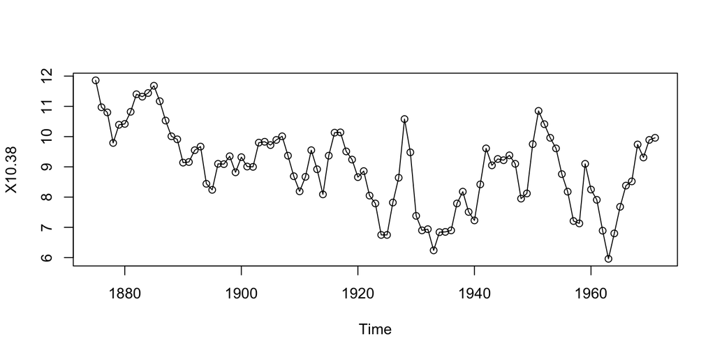

```r
  plot(Lake, type="o")
```

```r
  Fit2 <- Arima(Lake, order=c(1,0,1), xreg=time(Lake) )
  Fit2
```

```
## Series: Lake
## Regression with ARIMA(1,0,1) errors
##
## Coefficients:
##          ar1     ma1  intercept     xreg
##       0.6682  0.3817    55.5443  -0.0242
## s.e.  0.0936  0.1136    18.0324   0.0094
##
## sigma^2 estimated as 0.4612:  log likelihood=-98.66
## AIC=207.33   AICc=207.98   BIC=220.2
```

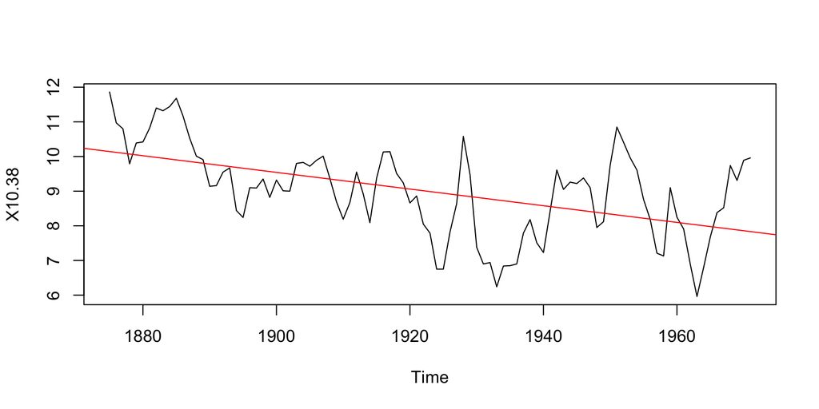

```r
  #- plot the regression line
  Reg2 <- lm(Lake~time(Lake))
  plot(Lake)
  abline(Reg2, col="red")
```

## Model 2 (linear trend)

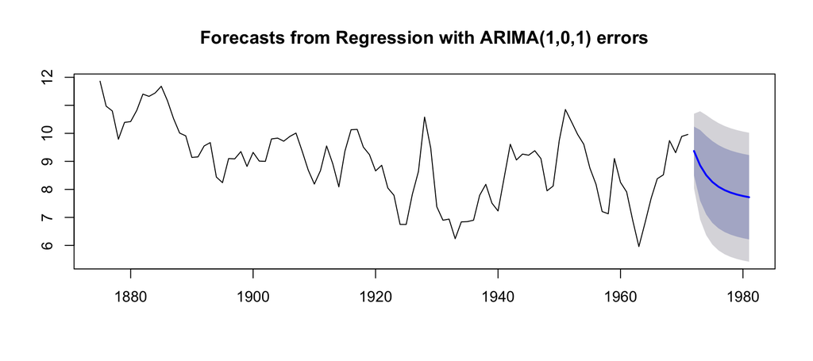

```r
  #--- 10-step prediction ---
  h=10
  plot(forecast(Fit2, h, xreg=last(time(Lake))+(1:h)/frequency(Lake)))
```

```r
  forecast(Fit2, h, xreg=last(time(Lake))+(1:h)/frequency(Lake))
```

```
##      Point Forecast    Lo 80     Hi 80    Lo 95    Hi 95
## 1972       9.369630 8.499292 10.239968 8.038563 10.70070
## 1973       8.857415 7.595493 10.119337 6.927472 10.78736
## 1974       8.507123 7.105238  9.909007 6.363126 10.65112
## 1975       8.265032 6.804977  9.725086 6.032071 10.49799
## 1976       8.095244 6.609951  9.580538 5.823684 10.36680
## 1977       7.973771 6.477345  9.470197 5.685185 10.26236
## 1978       7.884584 6.383214  9.385954 5.588436 10.18073
## 1979       7.816971 6.313398  9.320543 5.517454 10.11649
## 1980       7.763773 6.259218  9.268329 5.462755 10.06479
## 1981       7.720210 6.215216  9.225203 5.418520 10.02190
```

```
##
## Last  37  obs fit retrospectively
##     with Rolling 1-step prediction
##   Average prediction error:  0.2225
##   root Mean Squared Error:   0.7817
```

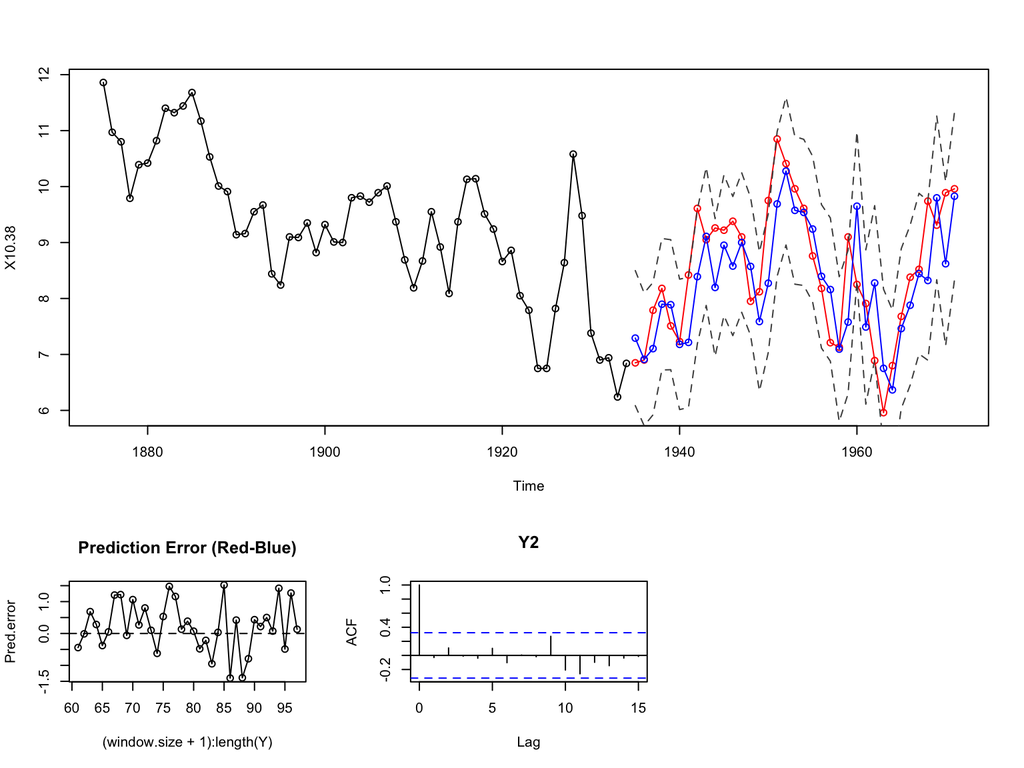

```
##      mean pred error   rMSE
## [1,]          0.2225 0.7817
```

```r
  #--- This line will load it to R
  source('https://nmimoto.github.io/R/TS-00.txt')


  #--- Set options (same as above)
  Y <- Lake                  # Original data
  window.size <- 60          # Window size for estimation
  Arima.order <- c(1,0,1)    # Arima(p,d,q) order
  pred.plot   <- TRUE        # do you want plot at end?

  # Arima() options:
  include.mean = TRUE        #
  include.drift = FALSE      #
  lambda   = NULL            # NULL=no transformaton. 0=Log
  xreg     = TRUE            # NULL=no xreg.  TRUE=Linear Trend is present
  seasonal = c(0, 0, 0)      # seasonal component

    #--- Use the function
    Rolling1step.forecast(Y, window.size, Arima.order, pred.plot,
                          include.mean, include.drift, lambda, xreg, seasonal)
```

# 3. Forecasting with ARIMA (Random Trend)

Let’s look at the difference between the observations:
$$diff(Y) = Y_t - Y_{t-1} \\ \\$$

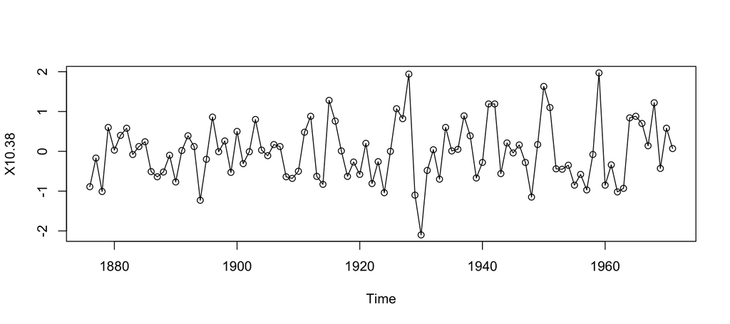

```r
  diff.Y <- diff(Lake)      # takes difference between the observations
  plot(diff.Y, type='o')
```

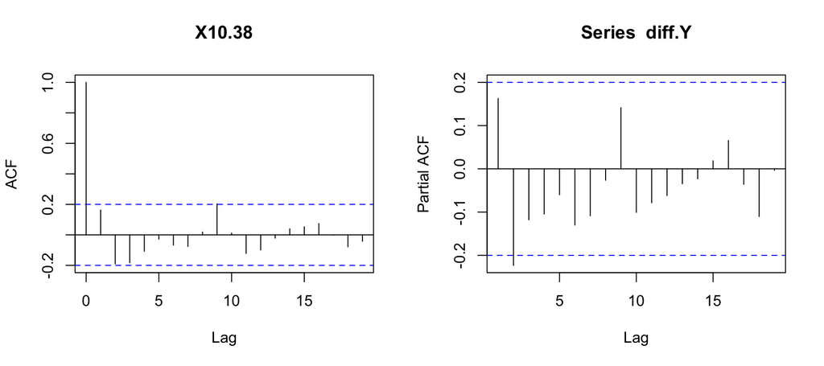

```r
  layout(matrix(1:2, 1, 2))
  acf(diff.Y)
  pacf(diff.Y)
```

```r
  layout(1)

  Fit3 <- Arima(Lake, order=c(1,1,2), include.drift=TRUE)
  Fit3
```

```
## Series: Lake
## ARIMA(1,1,2) with drift
##
## Coefficients:
##          ar1      ma1      ma2    drift
##       0.6911  -0.6271  -0.3729  -0.0241
## s.e.  0.0956   0.1251   0.1157   0.0100
##
## sigma^2 estimated as 0.4663:  log likelihood=-99
## AIC=208.01   AICc=208.67   BIC=220.83
```

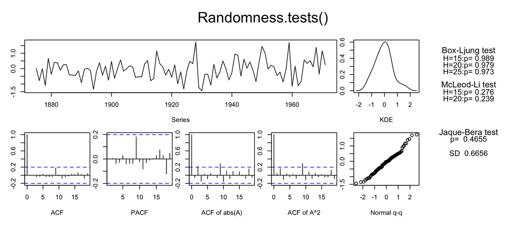

```
##   B-L test H0: the series is uncorrelated
##   M-L test H0: the square of the series is uncorrelated
##   J-B test H0: the series came from Normal distribution
##   SD         : Standard Deviation of the series
```

```
##       BL15  BL20  BL25  ML15  ML20    JB    SD
## [1,] 0.989 0.979 0.973 0.276 0.239 0.465 0.666
```

```r
  Randomness.tests(Fit3$residuals)
```

## Model 3 (take difference)

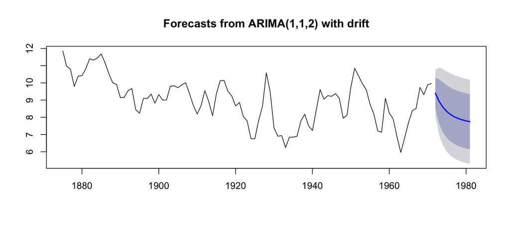

```r
  #--- 10-step prediction ---
  plot(forecast(Fit3, 10))
```

```r
  forecast(Fit3, 10)
```

```
##      Point Forecast    Lo 80     Hi 80    Lo 95    Hi 95
## 1972       9.406472 8.527087 10.285857 8.061569 10.75137
## 1973       8.919379 7.629143 10.209615 6.946133 10.89262
## 1974       8.575314 7.124264 10.026365 6.356124 10.79450
## 1975       8.330089 6.804788  9.855390 5.997342 10.66284
## 1976       8.153168 6.591336  9.714999 5.764552 10.54178
## 1977       8.023447 6.442886  9.604009 5.606187 10.44071
## 1978       7.926345 6.335830  9.516860 5.493862 10.35883
## 1979       7.851783 6.255788  9.447778 5.410920 10.29265
## 1980       7.792799 6.193677  9.391920 5.347154 10.23844
## 1981       7.744578 6.143610  9.345547 5.296109 10.19305
```

```
##
## Last  37  obs fit retrospectively
##     with Rolling 1-step prediction
##   Average prediction error:  0.2124
##   root Mean Squared Error:   0.7781
```

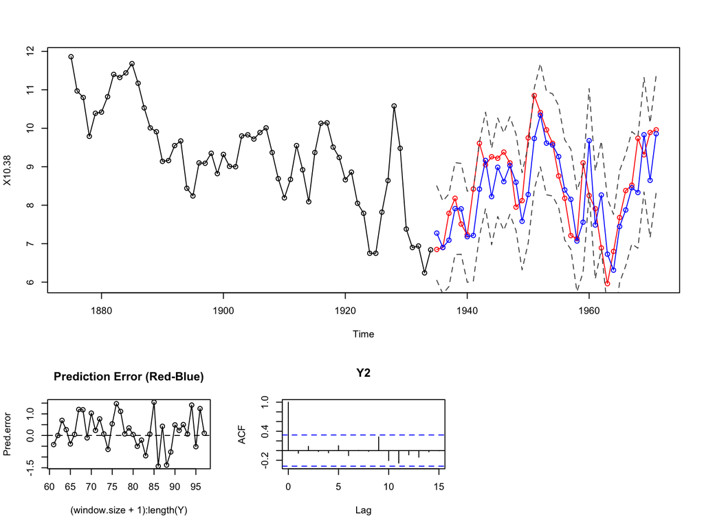

```
##      mean pred error   rMSE
## [1,]          0.2124 0.7781
```

```r
  #--- This line will load it to R
  source('https://nmimoto.github.io/R/TS-00.txt')


  #--- Set options (same as above)
  Y <- Lake                  # Original data
  window.size <- 60          # Window size for estimation
  Arima.order <- c(1,1,2)    # Arima(p,d,q) order
  pred.plot   <- TRUE        # do you want plot at end?

  # Arima() options:
  include.mean = TRUE        #
  include.drift = TRUE       #
  lambda   = NULL            # NULL=no transformaton. 0=Log
  xreg     = NULL            # NULL=no xreg.  TRUE=Linear Trend is present
  seasonal = c(0, 0, 0)      # seasonal component

    #--- Use the function
    Rolling1step.forecast(Y, window.size, Arima.order, pred.plot,
                          include.mean, include.drift, lambda, xreg, seasonal)
```

## Comparing MSE

- From Model1, 2, 3, estimate for $\sigma^2$ was $0.4784, \, 0.4612, \, 0.4663$ respectively.
- Taking square root, that means $\hat \sigma$ are $0.6917, \, 0.6791, \, 0.6828$
- On the other hand, rolling 1-step prediction rMSE for the three models were $0.8030, \, 0.7817, \, 0.7781$
- Why do they not agree? Which model is fitting the best?
- What is over-fittting?

# 4. ARIMA(p,d,q) Modeling Workflow

- Let $Y$ be the original time series.

### Preliminary Analysis

- Is $Y$ stationary? Use **Stationarity.tests()**. If all three points to stationarity, then set $d=0$ and perform ARMA(p,q) analysis.
- If above test is mixed or non-stationary, then take a difference of $Y$ by **diff(Y)**, and use **Stationarity.tests()**.
- If **Stationarity.tests( diff(Y) )** has all three tests pointing to stationarity, then set $d=1$, and use auto.arima() on $Y$.
- If **Stationarity.tests( diff(Y) )** has mixed answer, then you have to perform both $d=0$ analysis and $d=1$ analysis.
- If **Stationarity.tests( diff(Y) )** all points to non-stationarity, then you should take difference again by diff(diff(Y)).

### (1) d=0 Direct ARMA(p,q)

- Take no difference. Directly fit ARMA(p,q) with d=0. This is same as ARMA analysis.
- This model is assuming that $Y$ is stationary.

### (2) d=1 ARIMA with random trend

- Take difference once then fit ARMA(p,q). Use **auto.arima(Y, d=1)** with stepwise=FALSE and approximation=FALSE option.
- This model assumes $Y$ is not stationary, and either have random trend without drift, random trend with drift, or linear trend.
- If no drift term is suggested **auto.arima()**, include it using Arima(), and check for significance.

### (3) d=0 Linear Trend + ARMA(p,q)

- This model is assuming that $Y$ is not stationary, with linear deterministic trend.
- Do this if $Y$ appear to have a linear trend.
- For thie model to be valid, (2) must have significant drift term
- If this model is true, then residuals after regression must return stationary series. (Use **Reg = lm(Y~time(Y))** and **Reg$residuals**)
- Take no difference. Use **auto.arima(Y, d=0, xreg=time(y) )** with stepwise=FALSE and approximation=FALSE option.

[TS Class Webpage](https://nmimoto.github.io/477/) – [R resource page](https://nmimoto.github.io/R/)